# Lucidity

Musings presented by James Martin

### Hack Night Demo

29 Jan. 2015

On Thursday, January 29th, I gave a short demo at UNC Chapel Hill at the CS club's Hack Night about using IPython Notebook and Pandas to do quick data analysis. I looked at some sample data from [Ookla's Netmetrics](http://www.ookla.com/netmetrics) product. Afterwards, I answered questions and chatted with interested undergraduates. This post was entirely made with IPython Notebook.

## Installation

First, we're going to download [Anaconda](https://store.continuum.io/cshop/anaconda/), which is a nifty distribution of Python that contains everything we need. Be careful Googling for "anaconda," Nicki Minaj has a monopoly on the search results. ;)

- After running the bash script or opening the .exe file, pay close attention to the license agreement - it's easy to say "no" by accident.
- Choose to prepend your PATH variable with the anaconda/bin folder. This makes it much easier to launch IPython Notebook right away. If you have problems, stop me or look on with someone else.
- Also, run `conda update conda` and download any available updates.

When finished, create a new folder under your Documents or where you keep code to hold our notebooks; name it what you please. I call mine "notebooks."

- Open your flavor of terminal and navigate to your new notebooks folder.
- Execute the `ipython notebook` command

If you installed everything correctly, your default browser should pop up with a dashboard!

Now, we're going to download some sample data to have something to play with.

- Navigate to https://www.ookla.com/netmetrics and click "Download Sample Data." Remember where you save the zip folder.

I'm going to save it to a folder one directory above where my notebooks reside. Let's extract the folder and see what we have. You can run shell commands within cells using a "bang" (!).

```python
!ls ../data_samples
```

```
android_col_headers.txt ptnet_col_headers.txt   survey_col_headers.txt
android_data_sample.csv ptnet_data_sample.csv   survey_data_sample.csv
iphone_col_headers.txt  stnet_col_headers.txt   wp_col_headers.txt
iphone_data_sample.csv  stnet_data_sample.csv   wp_data_sample.csv
```

Okay, sweet, looks like we have some header files and some data in comma separated files, or .csv. Let's take a closer look at the iPhone data by seeing what sort of metrics Ookla collected.

```python
!cat ../data_samples/iphone_col_headers.txt
```

```
test_id - unique id of test in our system
device_id - unique device id in our system
test_date - YYYY-MM-DD HH:MM:SS in Pacific time (we can accommodate different timezones if needed)
client_ip - ip of client
download_kbps - download speed in kilobits per second
upload_kbps - upload speed in kilobits per second
latency_ms - ping in milliseconds
server_name - name of server tested to (name of city it is located in)
server_country - country name of server
server_country_code - country code of server
server_latitude - latitude of server tested to
server_longitude - longitude of server tested to
server_sponsor_name - sponsor name of server
client_country - country name of the client
client_country_code - country code of the client
client_region - region name of client (this will be state in the US)
client_region_code - region code of client
client_city - city of client
client_latitude - latitude of client (GPS or Maxmind when location services disabled)
client_longitude - longitude of client (GPS or Maxmind when location services disabled)
miles_between - miles between the client and the server tested to
connection_type - 0=unknown, 1=cell, 2=wifi, 3=GPRS, 4=Edge, 5=WCDMA, 6=HSDPA, 7=HSUPA, 8=CDMA1x, 9=CDMAEVDORev0, 10=CDMAEVDORevB, 11=eHRPD, 12=LTE
isp_name  - name of ISP (Maxmind)
is_isp    - 0=Corporation/Academic, 1=ISP
carrier_name - http://developer.apple.com/library/ios/documentation/NetworkingInternet/Reference/CTCarrier/Reference/Reference.html#//apple_ref/occ/instp/CTCarrier/carrierName
iso_country_code - http://developer.apple.com/library/ios/documentation/NetworkingInternet/Reference/CTCarrier/Reference/Reference.html#//apple_ref/occ/instp/CTCarrier/isoCountryCode
mobile_country_code - http://developer.apple.com/library/ios/documentation/NetworkingInternet/Reference/CTCarrier/Reference/Reference.html#//apple_ref/occ/instp/CTCarrier/mobileCountryCode
mobile_network_code - http://developer.apple.com/library/ios/documentation/NetworkingInternet/Reference/CTCarrier/Reference/Reference.html#//apple_ref/occ/instp/CTCarrier/mobileNetworkCode
model - iPad, iPhone, iPod Touch
version - iOS version
location_type - 0 = unknown, 1 = GPS, 2 = GeoIP
```

## Telling stories

So now we know what the data contains, let's think about what we want to find out... Say my carrier has been really slow on my phone and I don't think I'm getting very good network speeds when using cellular data. I want to shop for a new phone and can change carriers. Let's find out which carrier has the fastest average (mean) network speed!

First, we have to read the data in. Let's use one of my favorite Python libraries - Pandas.

```python
import pandas as pd
```

```python
df = pd.read_csv('../data_samples/iphone_data_sample.csv')
```

```python
df.info()
df.head()
```

```
<class 'pandas.core.frame.DataFrame'>
Int64Index: 5000 entries, 0 to 4999
Data columns (total 31 columns):
test_id                5000 non-null int64
iphone_device_id       5000 non-null int64
test_date              5000 non-null object
client_ip_address      5000 non-null object
download_kbps          5000 non-null int64
upload_kbps            5000 non-null int64
latency                5000 non-null int64
server_name            5000 non-null object
server_country         5000 non-null object
server_country_code    4998 non-null object
server_latitude        5000 non-null float64
server_longitude       5000 non-null float64
server_sponsor_name    4871 non-null object
client_country         5000 non-null object
client_country_code    4998 non-null object
client_region_name     5000 non-null object
client_region_code     5000 non-null object
client_city            5000 non-null object
client_latitude        5000 non-null float64
client_longitude       5000 non-null float64
miles_between          5000 non-null float64
connection_type        5000 non-null int64
isp_name               5000 non-null object
is_isp                 5000 non-null int64
carrier_name           4994 non-null object
iso_country_code       4873 non-null object
mobile_country_code    5000 non-null int64
mobile_network_code    5000 non-null int64
model                  5000 non-null object
version                5000 non-null object
location_type          5000 non-null int64
dtypes: float64(5), int64(10), object(16)
```

|  | test_id | iphone_device_id | test_date | client_ip_address | download_kbps | upload_kbps | latency | server_name | server_country | server_country_code | ... | connection_type | isp_name | is_isp | carrier_name | iso_country_code | mobile_country_code | mobile_network_code | model | version | location_type |
| --- | --- | --- | --- | --- | --- | --- | --- | --- | --- | --- | --- | --- | --- | --- | --- | --- | --- | --- | --- | --- | --- |
| 0 | 1053769770 | 42540590 | 2014-12-01 00:00:00 | 178.81.xxx.xxx | 11391 | 2420 | 99 | Jeddah | Saudi Arabia | SA | ... | 2 | Mobily | 1 | STC | SA | 420 | 1 | iPhone5S | 8.1.1 | 1 |
| 1 | 1053769771 | 55001812 | 2014-12-01 00:00:00 | 124.13.xxx.xxx | 544 | 4491 | 20 | Puchong | Malaysia | MY | ... | 2 | Telekom Malaysia | 1 | DiGi | MY | 502 | 16 | iPhone5 | 8.1.2 | 1 |
| 2 | 1053769772 | 55143153 | 2014-12-01 00:00:00 | 92.232.xxx.xxx | 42094 | 6098 | 10 | Birmingham | Great Britain | GB | ... | 2 | Virgin Media | 1 | Three | GB | 234 | 20 | iPhone5S | 8.1.2 | 1 |
| 3 | 1053769773 | 38269882 | 2014-12-01 00:00:00 | 91.99.xxx.xxx | 478 | 587 | 48 | Tehran | Iran | IR | ... | 2 | Pars Online PJS | 1 | Carrier | IR | 432 | 11 | iPhone5C | 8.1.2 | 1 |
| 4 | 1053769774 | 27035145 | 2014-12-01 00:00:00 | 37.216.xxx.xxx | 1 | 233 | 35 | Jeddah | Saudi Arabia | SA | ... | 12 | Mobily | 1 | Mobily | SA | 420 | 3 | iPhone5 | 8.1.2 | 1 |

5 rows × 31 columns

I just want to pause here real quick to explain Pandas DataFrames and Series. DataFrames are pretty much tables and Series are pretty much lists, if you want to read more, the [documentation for pandas](http://pandas.pydata.org/pandas-docs/version/0.15.1/) is very thorough.

Alright, now let's extract out the tests carried out in the United States with fairly straightforward boolean selection. Pandas is super flexible but it is also in-place, so we will have to store the selection as a new DataFrame.

```python
# We want to filter out tests not in the US and the tests that were on WiFi
us_tests = df[ (df['server_country_code'] == 'US') & (df['connection_type'] != 2)]
# We're also going to apply a lambda expression to make all the carrier names lowercase, for later use.
us_tests['carrier_name'] = us_tests['carrier_name'].apply(lambda x: x.lower())

# Keep an eye out for more lambda expressions in this demo, they are quite useful!
```

```python
us_tests.info()
us_tests.head()
```

```
<class 'pandas.core.frame.DataFrame'>
Int64Index: 84 entries, 5 to 4997
Data columns (total 31 columns):
test_id                84 non-null int64
iphone_device_id       84 non-null int64
test_date              84 non-null object
client_ip_address      84 non-null object
download_kbps          84 non-null int64
upload_kbps            84 non-null int64
latency                84 non-null int64
server_name            84 non-null object
server_country         84 non-null object
server_country_code    84 non-null object
server_latitude        84 non-null float64
server_longitude       84 non-null float64
server_sponsor_name    84 non-null object
client_country         84 non-null object
client_country_code    84 non-null object
client_region_name     84 non-null object
client_region_code     84 non-null object
client_city            84 non-null object
client_latitude        84 non-null float64
client_longitude       84 non-null float64
miles_between          84 non-null float64
connection_type        84 non-null int64
isp_name               84 non-null object
is_isp                 84 non-null int64
carrier_name           84 non-null object
iso_country_code       84 non-null object
mobile_country_code    84 non-null int64
mobile_network_code    84 non-null int64
model                  84 non-null object
version                84 non-null object
location_type          84 non-null int64
dtypes: float64(5), int64(10), object(16)
```

|  | test_id | iphone_device_id | test_date | client_ip_address | download_kbps | upload_kbps | latency | server_name | server_country | server_country_code | ... | connection_type | isp_name | is_isp | carrier_name | iso_country_code | mobile_country_code | mobile_network_code | model | version | location_type |
| --- | --- | --- | --- | --- | --- | --- | --- | --- | --- | --- | --- | --- | --- | --- | --- | --- | --- | --- | --- | --- | --- |
| 5 | 1053769775 | 55137640 | 2014-12-01 00:00:00 | 172.56.xxx.xxx | 4694 | 665 | 80 | Riverside, CA | United States | US | ... | 6 | T-MOBILE USA | 1 | t-mobile | US | 310 | 260 | iPhone5S | 8.1.1 | 1 |
| 36 | 1053769809 | 55143156 | 2014-12-01 00:00:04 | 172.56.xxx.xxx | 70643 | 28333 | 31 | Manhattan New York, NY | United States | US | ... | 12 | T-MOBILE USA | 1 | t-mobile | US | 310 | 260 | iPhone5S | 8.1.1 | 2 |
| 110 | 1053769903 | 55143161 | 2014-12-01 00:00:15 | 166.170.xxx.xxx | 10018 | 6074 | 39 | Los Angeles, CA | United States | US | ... | 12 | AT&T Wireless | 1 | at&t | US | 310 | 410 | iPhone5S | 8.1.1 | 2 |
| 139 | 1053769937 | 55123993 | 2014-12-01 00:00:18 | 166.171.xxx.xxx | 24819 | 18440 | 66 | Charlotte, NC | United States | US | ... | 12 | AT&T Wireless | 1 | at&t | US | 310 | 410 | iPhone5S | 8.1.1 | 1 |
| 243 | 1053770064 | 51721524 | 2014-12-01 00:00:32 | 172.56.xxx.xxx | 50966 | 10880 | 39 | Dallas, TX | United States | US | ... | 12 | T-MOBILE USA | 1 | t-mobile | US | 310 | 260 | iPhone5S | 8.1.2 | 1 |

5 rows × 31 columns

Now let's slice out the carrier names and find out which carriers were most popular during the test.

```python
carriers = us_tests['carrier_name']
# Yes, easy as that!
```

```python
# Let's make a quick histogram, so we'll pull in a few more libraries
import numpy as np
import matplotlib.pyplot as plt
from scipy import stats
```

```python
# These lines adjust the figures that will appear under code cells. We're also resizing the figure to be larger.
%matplotlib inline
import pylab
pylab.rcParams['figure.figsize'] = (10.0, 8.0)
```

```python
carrs = {}
for carrier in carriers:
    if carrier not in carrs:
        carrs[carrier] = 0
    carrs[carrier] = carrs[carrier] + 1
```

```python
carrs
```

```
{'aio': 1,
 'at&t': 26,
 'cricket': 2,
 'movistar': 1,
 'sprint': 11,
 'stc': 2,
 't-mobile': 29,
 'tfw': 1,
 'verizon': 11}
```

Now at this point our data set is limited to under 100, so we may not be able to provide key insights. But, with a larger data set, these exact same steps will produce a more meaningful story. Keep that in mind!

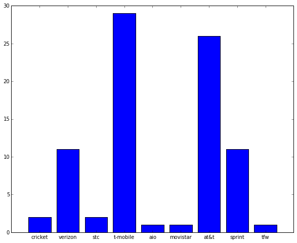

```python
plt.bar(range(len(carrs)), carrs.values(), align='center')
plt.xticks(range(len(carrs)), carrs.keys())

plt.show()
```

We can change the colors and add labels, but we'll skip that for now. It looks like the big carriers are represented pretty well, so let's find out the average speed for each.

```python
test = us_tests['download_kbps'].apply(lambda x: np.float64(x)*0.008)
test
```

```
5       37.552
36     565.144
110     80.144
139    198.552
243    407.728
314     72.080
374     59.536
386      3.720
396     51.032
398     94.184
405     35.328
456     66.440
489    128.784
518    138.496
802    382.968
```

[output cut: 17 more lines]

```python
ofinterest = carrs.keys()

for carrier in ofinterest:
    # Slice out carrier data
    carrier_data = us_tests[us_tests['carrier_name'] == carrier]
    latency = np.asarray(carrier_data['latency'])
    download_speed_mbs = np.asarray(carrier_data['download_kbps'].apply(lambda x: np.float64(x)*0.008))
    # Let's repurpose our old dictionary to contain the information we want.
    count = carrs[carrier]
    carrs[carrier] = [np.mean(latency), np.mean(download_speed_mbs), count]
```

```python
# To show off Pandas' flexibility, let's make a DataFrame out of our new dictionary!
final = pd.DataFrame.from_dict(carrs, orient="index") # Make sure to orient our keys as the index
final.head()
```

|  | 0 | 1 | 2 |
| --- | --- | --- | --- |
| cricket | 83.500000 | 25.396000 | 2 |
| verizon | 59.727273 | 209.888727 | 11 |
| stc | 570.500000 | 54.016000 | 2 |
| t-mobile | 67.000000 | 131.500414 | 29 |
| aio | 99.000000 | 66.440000 | 1 |

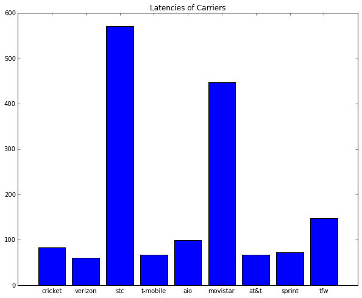

```python
# Now let's generate some plots!
latencies = final[0]
speeds = final[1]
plt.bar(range(len(carrs)), latencies, align='center')
plt.xticks(range(len(carrs)), final.index.values)
plt.title('Latencies of Carriers')

plt.show()
```

Okay, so no surprise here. It looks like Movistar and STC (two popular carriers outside the US) have high latencies. Now let's check out what we wanted!

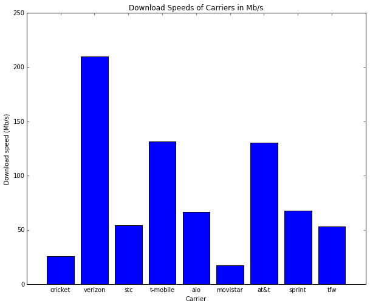

```python
plt.bar(range(len(carrs)), speeds, align='center')
plt.xticks(range(len(carrs)), final.index.values)
plt.title('Download Speeds of Carriers in Mb/s')
plt.xlabel('Carrier')
plt.ylabel('Download speed (Mb/s)')

plt.show()
```

## Conclusion

Big shoutout goes to [Pete Parente](http://www.mindtrove.info) for CSS layout of IPython Notebooks.

### Contact

jamesml@cs.unc.edu  
github.com/jlmartin9  
twitter.com/jamesmartweets  
instagram.com/jlmartin9

### Latest

Demo for Hack Night

### On Air

[interactive chart not shown]

All style and website layout courtesy of [Pete Parente](http://www.mindtrove.info). Website was built from scratch with inspiration drawn from Pete. Content (c) James Martin, 2015.